# Blocking: An R Package for Blocking of Records for Record Linkage and Deduplication

Entity resolution (probabilistic record linkage, deduplication) is essential for estimation based on multiple sources. It aims to link records without common identifiers that refer to the same entity (e.g., person, company). Without identifiers, researchers must specify which records to compare to calculate matching probability and reduce computational complexity. Traditional deterministic blocking uses common variables like names or dates of birth, but assumes error-free, complete data. To address this limitation, we developed the R package blocking, which uses approximate nearest neighbour search and graph algorithms to reduce comparisons. This paper presents the package design, functionalities, and two official statistics case studies.

Maciej Beręsewicz https://maciejberesewicz.com (University of Economics and BusinessStatisical Office in Poznań) , Adam Struzik (Adam Mickiewicz UniversityStatisical Office in Poznań)  
2025-11-09

## 1 Introduction

The following should be underlined:

- reduce number of comparisons
- reduce FNR and other errors
- reduce workload on clerical review

## 2 Background

Some packages on interactive graphics include plotly (Sievert 2020) that interfaces with Javascript for web-based interactive graphics, crosstalk (Cheng and Sievert 2021) that specializes cross-linking elements across individual graphics. The recent R Journal paper tsibbletalk (Wang and Cook 2021) provides a good example of including interactive graphics into an article for the journal. It has both a set of linked plots, and also an animated gif example, illustrating linking between time series plots and feature summaries.

## 3 Blocking of records using `blocking` function

### 3.1 The main function

### 3.2 Assessment of results

In the package we have implemented several measures that can be used to assess the results

**Reduction Ratio**: Provides necessary details about the reduction in comparison pairs if the given blocks are applied to a further record linkage or deduplication procedure. For deduplication:

$$\text{RR}_{\text{deduplication}} = 1 - \frac{\sum\limits_{i=1}^{k} \binom{|B_i|}{2}}{\binom{n}{2}},$$

where $k$ is the total number of blocks, $n$ is the total number of records in the dataset, and $|B_i|$ is the number of records in the $i$-th block. $\sum\limits_{i=1}^{k} \binom{|B_i|}{2}$ is the number of comparisons after blocking, while $\binom{n}{2}$ is the total number of possible comparisons without blocking. For record linkage the reduction ratio is defined as follows

$$\text{RR}_{\text{record\_linkage}} = 1 - \frac{\sum\limits_{i=1}^{k} |B_{i,x}| \cdot |B_{i,y}|} {(m \cdot n)},$$

where $m$ and $n$ are the sizes of datasets $X$ and $Y$, and $k$ is the total number of blocks. The term $|B_{i,x}|$ is the number of unique records from dataset $X$ in the $i$-th block, while $|B_{i,y}|$ is the number of unique records from dataset $Y$ in the $i$-th block. The expression $\sum\limits_{i=1}^{k} |B_{i,x}| \cdot |B_{i,y}|$ is the number of comparisons after blocking.

Confusion matrix presents results in comparison to ground-truth in a pairwise manner (e.g., one true positive pair occurs when both records from the comparison pair belong to the same predicted and to the same ground-truth in the evaluation data frame).

- True Positive (TP): Record pairs correctly matched in the same block.
- False Positive (FP): Records pairs identified as matches that are not true matches in the same block.
- True Negative (TN): Record pairs correctly identified as non-matches (different blocks)
- False Negative (FN): Records identified as non-matches that are true matches in the same block.

| **Metric** | **Formula** | **Metric** | **Formula** |
| --- | --- | --- | --- |
| Recall | $\frac{TP}{TP + FN}$ | Accuracy | $\frac{TP + TN}{TP + TN + FP + FN}$ |
| Precision | $\frac{TP}{TP + FP}$ | Specificity | $\frac{TN}{TN + FP}$ |
| F1 Score | $2 \cdot \frac{\text{Precision} \times \text{Recall}}{\text{Precision} + \text{Recall}}$ | False Positive Rate | $\frac{FP}{FP + TN}$ |
| False Negative Rate | $\frac{FN}{FN + TP}$ |  |  |

*Table: Evaluation Metrics*

## 4 Case studies

### 4.1 Record linkage example

Let us first load the required packages.

```r
library(blocking)
library(data.table)
```

We demonstrate the use of `blocking` function for record linkage on the `foreigners` dataset included in the package. This fictional representation of the foreign population in Poland was generated based on publicly available information, preserving the distributions from administrative registers. It contains 110,000 rows with 100,000 entities. Each row represents one record, with the following columns:

- `fname` – first name,
- `sname` – second name,
- `surname` – surname,
- `date` – date of birth,
- `region` – region (county),
- `country` – country,
- `true_id` – person ID.

```r
data(foreigners)
head(foreigners)
```

```
    fname  sname    surname       date region country true_id
   <char> <char>     <char>     <char> <char>  <char>   <num>
1:   emin            imanov 1998/02/05            031       0
2: nurlan        suleymanli 2000/08/01            031       1
3:   amio        maharrsmov 1939/03/08            031       2
4:   amik        maharramof 1939/03/08            031       2
5:   amil        maharramov 1993/03/08            031       2
6:  gadir        jahangirov 1991/08/29            031       3
```

We split the dataset into two separate files: one containing the first appearance of each entity in the `foreigners` dataset, and the other containing its subsequent appearances.

```r
foreigners_1 <- foreigners[!duplicated(foreigners$true_id), ]
foreigners_2 <- foreigners[duplicated(foreigners$true_id), ]
```

Now in both datasets we remove slashes from the `date` column and create a new string column that concatenates the information from all columns (excluding `true_id`) in each row.

```r
foreigners_1[, date := gsub("/", "", date)]
foreigners_1[, txt := paste0(fname, sname, surname, date, region, country)]
foreigners_2[, date := gsub("/", "", date)]
foreigners_2[, txt := paste0(fname, sname, surname, date, region, country)]
head(foreigners_1)
```

```
    fname  sname    surname     date region country true_id
   <char> <char>     <char>   <char> <char>  <char>   <num>
1:   emin            imanov 19980205            031       0
2: nurlan        suleymanli 20000801            031       1
3:   amio        maharrsmov 19390308            031       2
4:  gadir        jahangirov 19910829            031       3
5:   zaur         bayramova 19961006  01261     031       4
6:   asif          mammadov 19970726            031       5
                             txt
                          <char>
1:         eminimanov19980205031
2:   nurlansuleymanli20000801031
3:     amiomaharrsmov19390308031
4:    gadirjahangirov19910829031
5: zaurbayramova1996100601261031
6:       asifmammadov19970726031
```

#### General use

We use the newly created columns in the `blocking` function, which relies on the default rnndescent (Nearest Neighbor Descent) algorithm based on cosine distance. Additionally, we set `verbose = 1` to monitor progress. Note that a default parameter of the `blocking` function is `seed = 2023`, which sets the random seed.

```r
result_reclin <- blocking(x = foreigners_1$txt,
                          y = foreigners_2$txt,
                          verbose = 1)
```

```
===== creating tokens =====
===== starting search (nnd, x, y: 100000, 10000, t: 1232) =====
===== creating graph =====
```

Now we examine the results of record linkage.

- We have created 6,470 blocks.
- The blocking process utilized 1,232 columns (2 character shingles).
- We have 3,920 blocks of 2 elements, 1,599 blocks of 3 elements,…, 2 blocks of 7 elements.

```r
result_reclin
```

```
========================================================
Blocking based on the nnd method.
Number of blocks: 6470.
Number of columns used for blocking: 1232.
Reduction ratio: 0.9999.
========================================================
Distribution of the size of the blocks:
   2    3    4    5    6    7
3920 1599  928   19    2    2
```

Structure of the object is as follows:

- `result` – a `data.table` with identifiers and block IDs,
- `method` – name of the ANN algorithm used,
- `deduplication` – whether deduplication was applied,
- `representation` – whether shingles or vectors were used,
- `metrics` – metrics for quality assessment (here `NULL`),
- `confusion` – confusion matrix (here `NULL`),
- `colnames` – column names used for the comparison,
- `graph` – an igraph object, mainly for visualization (here `NULL`).

```r
str(result_reclin, 1)
```

```
List of 8
 $ result        :Classes 'data.table' and 'data.frame':    10000 obs. of  4 variables:
  ..- attr(*, ".internal.selfref")=<externalptr>
 $ method        : chr "nnd"
 $ deduplication : logi FALSE
 $ representation: chr "shingles"
 $ metrics       : NULL
 $ confusion     : NULL
 $ colnames      : chr [1:1232] "0a" "0b" "0c" "0m" ...
 $ graph         : NULL
 - attr(*, "class")= chr "blocking"
```

The resulting `data.table` has four columns:

- `x` – reference dataset (i.e. `foreigners_1`) – this may not contain all units of `foreigners_1`,
- `y` – query (each row of `foreigners_2`) – this may not contain all units of `foreigners_2`,
- `block` – block ID,
- `dist` – distance between objects.

```r
head(result_reclin$result)
```

```
       x     y block      dist
   <int> <int> <num>     <num>
1:     3     1     1 0.2216882
2:     3     2     1 0.2122737
3:    21     3     2 0.1172652
4:    57     4     3 0.1863238
5:    57     5     3 0.1379310
6:    61     6     4 0.2307692
```

Let’s examine the first pair. Obviously, there are typos in the `fname` and `surname`. Nevertheless, the pair is a match.

```r
cbind(t(foreigners_1[3, 1:6]), t(foreigners_2[1, 1:6]))
```

```
        [,1]         [,2]
fname   "amio"       "amik"
sname   ""           ""
surname "maharrsmov" "maharramof"
date    "19390308"   "19390308"
region  ""           ""
country "031"        "031"
```

Now we use the `true_id` values to evaluate our approach.

```r
matches <- merge(x = foreigners_1[, .(x = 1:.N, true_id)],
                 y = foreigners_2[, .(y = 1:.N, true_id)],
                 by = "true_id")
matches[, block := rleid(x)]
head(matches)
```

```
Key: <true_id>
   true_id     x     y block
     <num> <int> <int> <int>
1:       2     3     1     1
2:       2     3     2     1
3:      20    21     3     2
4:      56    57     4     3
5:      56    57     5     3
6:      60    61     6     4
```

We have 10,000 matched pairs. We use the `true_blocks` parameter in the `blocking` function to specify the true block assignments. We obtain the quality metrics for the assessment of record linkage.

```r
result_2_reclin <- blocking(x = foreigners_1$txt,
                            y = foreigners_2$txt,
                            verbose = 1,
                            true_blocks = matches[, .(x, y, block)])
```

```
===== creating tokens =====
===== starting search (nnd, x, y: 100000, 10000, t: 1232) =====
===== creating graph =====
```

```r
result_2_reclin
```

```
========================================================
Blocking based on the nnd method.
Number of blocks: 6470.
Number of columns used for blocking: 1232.
Reduction ratio: 0.9999.
========================================================
Distribution of the size of the blocks:
   2    3    4    5    6    7
3920 1599  928   19    2    2
========================================================
Evaluation metrics (standard):
     recall   precision         fpr         fnr    accuracy
    96.7532     78.6700      0.0038      3.2468     99.9957
specificity    f1_score
    99.9962     86.7795
```

For example, our approach results in a 3.25% false negative rate (FNR). To improve this, we can increase the `epsilon` parameter of the NND method from 0.1 to 0.5. To do so, we configure the `control_ann` parameter in the `blocking` function using the `controls_ann` and `control_nnd` functions.

```r
result_3_reclin <- blocking(x = foreigners_1$txt,
                            y = foreigners_2$txt,
                            verbose = 1,
                            true_blocks = matches[, .(x, y, block)],
                            control_ann = controls_ann(nnd = control_nnd(epsilon = 0.5)))
```

```
===== creating tokens =====
===== starting search (nnd, x, y: 100000, 10000, t: 1232) =====
===== creating graph =====
```

```r
result_3_reclin
```

```
========================================================
Blocking based on the nnd method.
Number of blocks: 6394.
Number of columns used for blocking: 1232.
Reduction ratio: 0.9999.
========================================================
Distribution of the size of the blocks:
   2    3    4    5    7
3800 1615  954   21    4
========================================================
Evaluation metrics (standard):
     recall   precision         fpr         fnr    accuracy
    96.8776     80.0500      0.0036      3.1224     99.9960
specificity    f1_score
    99.9964     87.6636
```

That decreases the FNR to 3.12%.

### 4.2 Deduplication example

We demonstrate deduplication using the `blocking` function on the `RLdata500` dataset from the RecordLinkage package. Note that the dataset is included in the `blocking` package. It contains artificial personal data. Fifty records have been duplicated with randomly generated errors. Each row represents one record, with the following columns:

- `fname_c1` – first name, first component,
- `fname_c2` – first name, second component,
- `lname_c1` – last name, first component,
- `lname_c2` – last name, second component,
- `by` – year of birth,
- `bm` – month of birth,
- `bd` – day of birth,
- `rec_id` – record id,
- `ent_id` – entity id.

```r
data(RLdata500)
head(RLdata500)
```

```
   fname_c1 fname_c2 lname_c1 lname_c2    by    bm    bd rec_id
     <char>   <char>   <char>   <char> <int> <int> <int>  <int>
1:  CARSTEN             MEIER           1949     7    22      1
2:     GERD             BAUER           1968     7    27      2
3:   ROBERT          HARTMANN           1930     4    30      3
4:   STEFAN             WOLFF           1957     9     2      4
5:     RALF           KRUEGER           1966     1    13      5
6:  JUERGEN            FRANKE           1929     7     4      6
   ent_id
    <int>
1:     34
2:     51
3:    115
4:    189
5:     72
6:    142
```

We create a new column (`id_count`) that indicates how many times a given unit occurs and then add leading zeros to the `bm` and `bd` columns. Finally, we create a new string column that concatenates the information from all columns (excluding `rec_id`, `ent_id` and `id_count`) in each row.

```r
RLdata500[, id_count :=.N, ent_id]
RLdata500[, bm:=sprintf("%02d", bm)]
RLdata500[, bd:=sprintf("%02d", bd)]
RLdata500[, txt:=tolower(
  paste0(fname_c1,fname_c2,lname_c1,lname_c2,by,bm,bd))]
head(RLdata500)
```

```
   fname_c1 fname_c2 lname_c1 lname_c2    by     bm     bd rec_id
     <char>   <char>   <char>   <char> <int> <char> <char>  <int>
1:  CARSTEN             MEIER           1949     07     22      1
2:     GERD             BAUER           1968     07     27      2
3:   ROBERT          HARTMANN           1930     04     30      3
4:   STEFAN             WOLFF           1957     09     02      4
5:     RALF           KRUEGER           1966     01     13      5
6:  JUERGEN            FRANKE           1929     07     04      6
   ent_id id_count                    txt
    <int>    <int>                 <char>
1:     34        1   carstenmeier19490722
2:     51        2      gerdbauer19680727
3:    115        1 roberthartmann19300430
4:    189        1    stefanwolff19570902
5:     72        1    ralfkrueger19660113
6:    142        1  juergenfranke19290704
```

As in the previous example, we use the `txt` column in the `blocking` function. This time, we set `ann = hnsw` to use the Hierarchical Navigable Small World (HNSW) algorithm from the RcppHNSW package and `graph = TRUE` to obtain an igraph object for visualization.

```r
result_dedup_hnsw <- blocking(x = RLdata500$txt,
                              ann = "hnsw",
                              graph = TRUE,
                              verbose = 1)
```

```
===== creating tokens =====
===== starting search (hnsw, x, y: 500, 500, t: 429) =====
===== creating graph =====
```

The results are as follows.

```r
result_dedup_hnsw
```

```
========================================================
Blocking based on the hnsw method.
Number of blocks: 133.
Number of columns used for blocking: 429.
Reduction ratio: 0.9916.
========================================================
Distribution of the size of the blocks:
 2  3  4  5  6  7  8  9 10 11 12 17
46 35 23  8  6  6  2  3  1  1  1  1
```

```r
head(result_dedup_hnsw$result)
```

```
       x     y block       dist
   <int> <int> <num>      <num>
1:     1    64    35 0.47379863
2:     2    43     1 0.08074522
3:     2   486     1 0.41023219
4:     3   450    88 0.43263358
5:     4    50    13 0.52565831
6:     5   128     2 0.51333570
```

Now we visualize connections using the obtained graph.

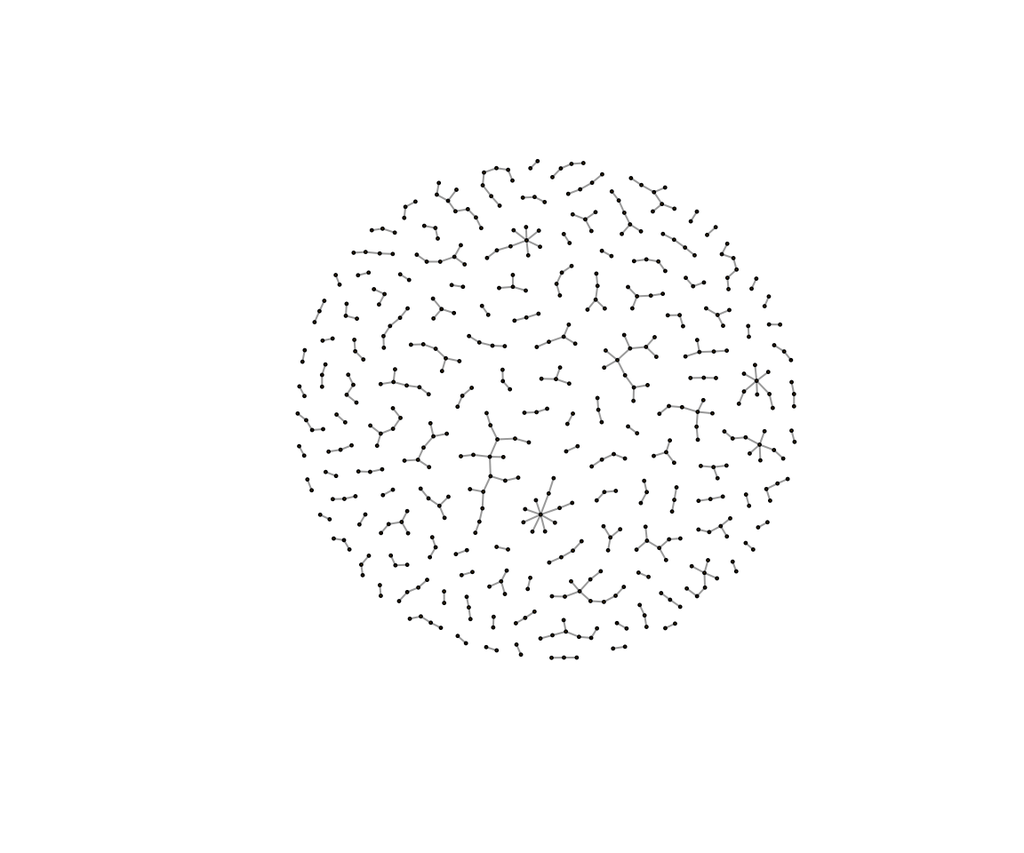

Figure 1: Connection graph

```r
plot(result_dedup_hnsw$graph, vertex.size = 1, vertex.label = NA)
```

We create a long `data.table` with information on blocks and units from the original dataset.

```r
df_block_melted <- melt(result_dedup_hnsw$result, id.vars = c("block", "dist"))
df_block_melted_rec_block <- unique(df_block_melted[, .(rec_id=value, block)])
head(df_block_melted_rec_block)
```

```
   rec_id block
    <int> <num>
1:      1    35
2:      2     1
3:      3    88
4:      4    13
5:      5     2
6:      6    35
```

We add the block information to the final dataset.

```r
RLdata500[df_block_melted_rec_block, on = "rec_id", block_id := i.block]
head(RLdata500)
```

```
   fname_c1 fname_c2 lname_c1 lname_c2    by     bm     bd rec_id
     <char>   <char>   <char>   <char> <int> <char> <char>  <int>
1:  CARSTEN             MEIER           1949     07     22      1
2:     GERD             BAUER           1968     07     27      2
3:   ROBERT          HARTMANN           1930     04     30      3
4:   STEFAN             WOLFF           1957     09     02      4
5:     RALF           KRUEGER           1966     01     13      5
6:  JUERGEN            FRANKE           1929     07     04      6
   ent_id id_count                    txt block_id
    <int>    <int>                 <char>    <num>
1:     34        1   carstenmeier19490722       35
2:     51        2      gerdbauer19680727        1
3:    115        1 roberthartmann19300430       88
4:    189        1    stefanwolff19570902       13
5:     72        1    ralfkrueger19660113        2
6:    142        1  juergenfranke19290704       35
```

We can check in how many blocks the same entities (`ent_id`) are observed. In our example, all the same entities are in the same blocks.

```r
RLdata500[, .(uniq_blocks = uniqueN(block_id)), .(ent_id)][, .N, uniq_blocks]
```

```
   uniq_blocks     N
         <int> <int>
1:           1   450
```

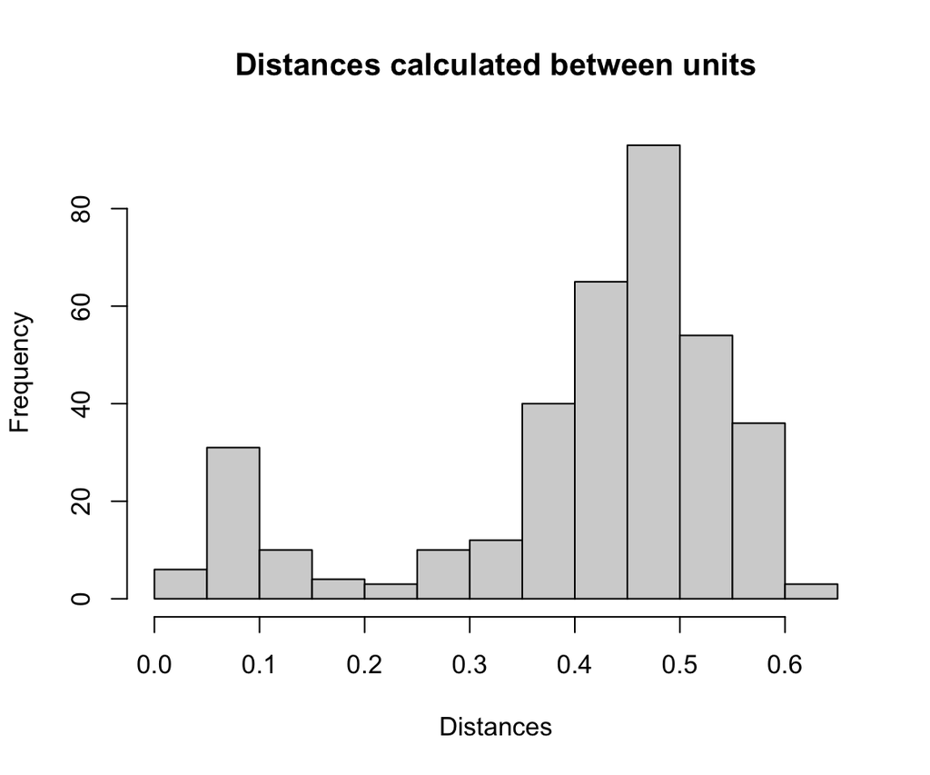

Figure 2: Distances calculated between units

```r
hist(result_dedup_hnsw$result$dist, xlab = "Distances",
     ylab = "Frequency", breaks = "fd",
     main = "Distances calculated between units")
```

Finally, we visualize the result based on the information whether a block contains matches or not.

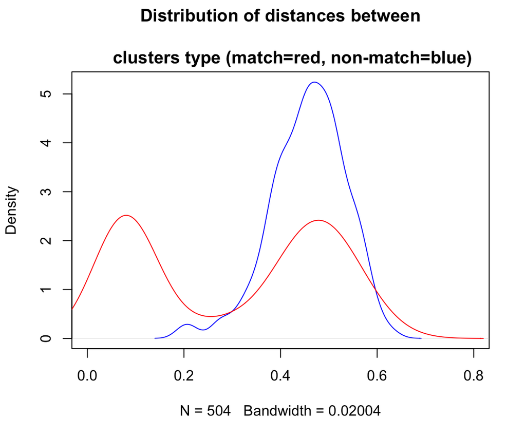

Figure 3: Distribution of distances between clusters type

```r
df_for_density <- copy(df_block_melted[block %in% RLdata500$block_id])
df_for_density[, match:= block %in% RLdata500[id_count == 2]$block_id]

plot(density(df_for_density[match==FALSE]$dist),
     col = "blue", xlim = c(0, 0.8),
     main = "Distribution of distances between\n
     clusters type (match=red, non-match=blue)")
lines(density(df_for_density[match==TRUE]$dist),
      col = "red", xlim = c(0, 0.8))
```

Now we compare the evaluation metrics across all ANN algorithms supported by the `blocking` function, i.e. NND, HNSW, Approximate Nearest Neighbors Oh Yeah (Annoy, from the RcppAnnoy package), Locality-sensitive hashing (LSH, from the mlpack package), and k-Nearest Neighbors (kNN – denoted as `"kd"`, from the mlpack package). We use the `rec_id` and `ent_id` columns from the `RLdata500` dataset to specify the true blocks and then calculate evaluation metrics for all algorithms. Additionally, we assess blocking using the `klsh` function from the klsh package, configured to create 10 blocks and 100 blocks, respectively. In both settings, we use 20 random projections and 2-character shingles. The results are as follows (`klsh_10` and `klsh_100` refer to the `klsh` algorithm with 10 blocks and 100 blocks, respectively).

```r
true_blocks <- RLdata500[, c("rec_id", "ent_id"), with = FALSE]
setnames(true_blocks, old = c("rec_id", "ent_id"), c("x", "block"))
eval_metrics <- list()
ann <- c("nnd", "hnsw", "annoy", "lsh","kd")
for (algorithm in ann) {
  eval_metrics[[algorithm]] <- blocking(x = RLdata500$txt,
                                ann = algorithm,
                                true_blocks = true_blocks)$metrics
}

set.seed(2025)
blocks_klsh_10 <- klsh::klsh(
  r.set = RLdata500[, c("fname_c1", "fname_c2", "lname_c1",
                        "lname_c2", "by", "bm", "bd")],
  p = 20,
  num.blocks = 10,
  k = 2)
klsh_10_metrics <- klsh::confusion.from.blocking(
  blocking = blocks_klsh_10,
  true_ids = RLdata500$ent_id)[-1]
klsh_10_metrics$f1_score <- 2 * klsh_10_metrics$precision *
  klsh_10_metrics$recall /
  (klsh_10_metrics$precision + klsh_10_metrics$recall)
eval_metrics$klsh_10 <- unlist(klsh_10_metrics)
blocks_klsh_100 <- klsh::klsh(
  r.set = RLdata500[, c("fname_c1", "fname_c2", "lname_c1",
                        "lname_c2", "by", "bm", "bd")],
  p = 20,
  num.blocks = 100,
  k = 2)
klsh_100_metrics <- klsh::confusion.from.blocking(
  blocking = blocks_klsh_100,
  true_ids = RLdata500$ent_id)[-1]
klsh_100_metrics$f1_score <- 2 * klsh_100_metrics$precision *
  klsh_100_metrics$recall /
  (klsh_100_metrics$precision + klsh_100_metrics$recall)
eval_metrics$klsh_100 <- unlist(klsh_100_metrics)

do.call(rbind, eval_metrics) * 100
```

```
         recall precision       fpr fnr accuracy specificity f1_score
nnd         100 5.1706308 0.7353649   0 99.26493    99.26464 9.832842
hnsw        100 4.7573739 0.8027265   0 99.19760    99.19727 9.082652
annoy       100 4.8030740 0.7947073   0 99.20561    99.20529 9.165903
lsh          98 1.0403397 3.7377706   2 96.26293    96.26223 2.058824
kd          100 5.1921080 0.7321572   0 99.26814    99.26784 9.871668
klsh_10      82 0.3290794 9.9582999  18 90.03848    90.04170 0.655528
klsh_100     86 3.4649476 0.9607057  14 99.03407    99.03929 6.661503
```

## 5 Summary

In this paper we have demonstrated the basic use cases of the blocking package. We believe that the software will be useful for researchers working in various fields where integration of multiple sources is an important aspect.

## 6 Acknowledgements

Work on this package is supported by the National Science Centre, OPUS 20 grant no. 2020/39/B/HS4/00941. We also thank participants of the uRos 2024 conference for valuable comments and discussion.

We also have developed a python version of the package {BlockingPy} that is available through the PiPy. It has the similar structure but offers more ANN algorithms (e.g. FAISS) or usage of embeddings. For more details see: Strojny, T., & Beręsewicz, M. (2025). BlockingPy: approximate nearest neighbours for blocking of records for entity resolution. arXiv preprint arXiv:2504.04266.

### 6.1 CRAN packages used

blocking, plotly, crosstalk, tsibbletalk, rnndescent, igraph, RecordLinkage, RcppHNSW, RcppAnnoy, mlpack, klsh

### 6.2 CRAN Task Views implied by cited packages

DynamicVisualizations, GraphicalModels, MachineLearning, NetworkAnalysis, OfficialStatistics, Optimization, TimeSeries, WebTechnologies

J. Cheng and C. Sievert. *crosstalk: Inter-widget interactivity for HTML widgets.* 2021. URL https://CRAN.R-project.org/package=crosstalk. R package version 1.1.1.

C. Sievert. *Interactive Web-Based Data Visualization with r, plotly, and shiny.* Chapman; Hall/CRC, 2020. URL https://plotly-r.com.

E. Wang and D. Cook. Conversations in time: Interactive visualisation to explore structured temporal data. *The R Journal*, 2021. URL https://journal.r-project.org/archive/2021/RJ-2021-050/index.html.